# manuscript_outline

2025-05-23

# Title Page

A generalizable tool for predicting developmental phenology for wild poikilotherms.

Morgan M. Sparks, Brian Leavell, Bryan M. Maitland

# Abstract

Before exogenous feeding, poikilothermic organisms have a near mechanistic relationship between ambient temperature and developmental rates. As such, statistical models can be easily developed to predict when organisms develop. Until recently, most models only used non-variable developmental regimes making them difficult to apply to wild environments. However, the R package hatchR formalized an approach using effective values where each day is given a developmental unit, accurately predicting developmental phenology for wild poikilotherms. hatchR was developed specific to fish, however this manuscript broadens the tool’s application showing how it can be used to predict developmental phenology for a broad range of taxa, including amphibians, reptiles, and invertebrates. Moreover, we provide numerous examples of how this approach informs scenarios from applied management to basic questions regarding ecological and evolutionary questions.

# Introduction

P1: Poikilotherms and ambient temperatures

P2: ATU models and effective value models

P3: Examples with other species

P4: Our approach here (R package and Shiny app)

# Methods

## Effective value models

Effective value models function by leveraging the statistical relationship derived from raising poikilotherms at different temperatures and fitting that relationsip with a non-linear model. The formultation of that relationship can then be reciprocated which provides the unit of development for a day’s average temperature–an effective value. Effective value models function then by cumulatively summing to one at which the organism achieves the development of the parameterized trait.

The model follows the general format of:

$$Effective Value_i = 1/exp(log_ea - log_e(Temperature_i - b))$$

Where *i* is the daily value and a fish hatches or emerges when the cumulative sum reaches one:
$$\sum_{i =1}^nEffectiveValue_i = 1$$

As an example, we parameterize an effective value model for western tailed frogs (*Ascaphus truei*) common to western North America (Figure 1). Custom parameterized models use the `fit_model()` function in hatchR, which is built on model 2 using the power law from Beacham and Murray (1990). Alternatively, to actually predict phenology using hatchR, the `predict_phenology()` only expects a model expression as input and could assume other model formulations custom built outside of the package by the user.

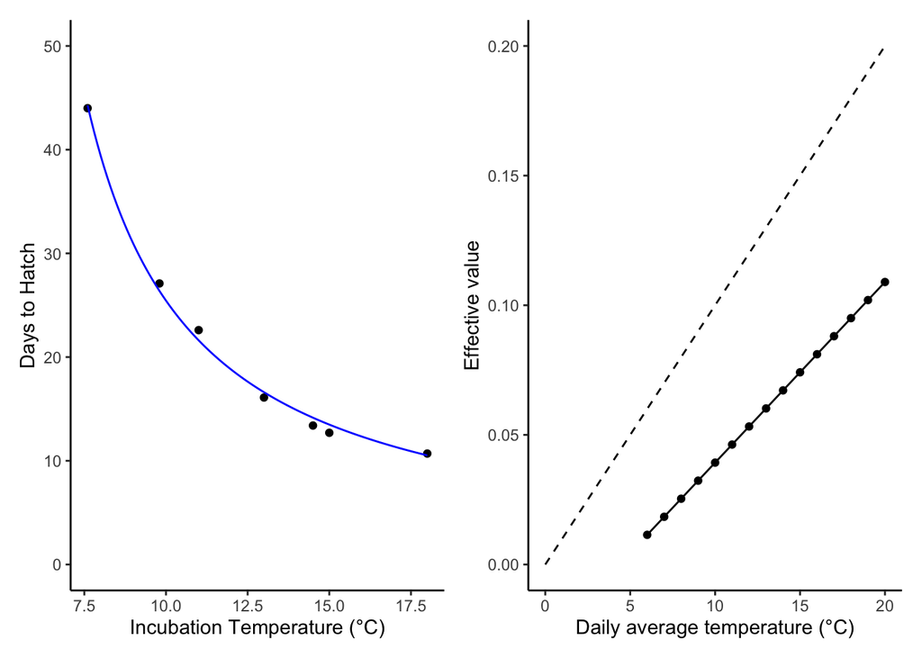

## Data and data checks

hatchR requires two essential paired vectors of data, one of daily average temperature and the other the date for those temperatures. The software is designed to function around common field temperature loggers and provides users the ability to summarize temperatures with multiple daily recordings.

### Data input

Maybe include the below:

Example temperature data for use in hatchR.

| date | temperature |
| --- | --- |
| 2000-01-01 | 2.51 |
| … | … |
| 2000-07-01 | 16.32 |
| … | … |
| 2000-12-31 | 3.13 |

If you import data from raw files with multiple daily readings, the package allows you to summarize your with `summarize_temp()` and then check summarized data with the `plot_check_temp()` and `check_continuous()` functions.

## Predicting phenology

hatchR has two function to predict phenology. The first is `predict_phenology()` where users input date of reproductive event (`spawn.date`) along with their daily average temperature and corresponding dates. Alternatively, the function `predict_spawn()` leverages the effective value model framework but works backward from observed or expected development. For example, if a user observed one of the many frog or reptile parameterizations below in an area where they had accurate temperature measurements, they could easily estimate when those individuals adults mated.

# Case studies

| Class | Order | Genera | Species | Study |
| --- | --- | --- | --- | --- |
| Amphibia | Anura | *Lithobates* | *L. sylvaticus* | Moore (1939) |
|  |  |  | *L. pipiens* |  |
|  |  |  | *L. clamitans* |  |
|  |  |  | *L. palustris* |  |
|  |  | *Ascaphus* | *A. truei* | Herbert A. Brown (1975) |
|  | Urodela | *Ambystoma* | *A. gracile* | Herbert A. Brown (1976) |
| Reptilia | Squamata | *Sceloporus* | *S. undulatus* | Angilletta, Winters, and Dunham (2000) |
|  |  | Podarcis | *P. mural*is | Van Damme et al. (1992) |
|  | Testudines | Mauremys | M. reevesii | Du et al. (2007) |
|  |  |  | 181 species | 141 studies in While et al. (2018) |
| Insecta | Plecoptera | *Nemurella* | *N. pictetii* | John E. Brittain (1978), Elliott (1984) |
|  |  | *Capnia* | *C. atra* | John E. Brittain and Mutch (1984) |
|  |  | *Capnia* | *C. bifrons* | Elliott (1986) |
|  |  | *Mesocapnia* | *M. oenone* | John E. Brittain and Mutch (1984) |
|  |  | *Taeniopteryx* | *T. nebulosa* | J. E. Brittain (1977) |
| Malacostraca | Decapoda | *Pontastacus* | *P. leptodactylus* | Aydın and Dilek (2004) |

While et al. (2018) not vetted for completeness

Pritchard and Leggott (1987) contains examples of power equations for 18 insect species

examples where other stages could be modeled assuming constant feeding (Lillehammer 1986)

## Local Adaptation

Need an example where multiple populations from the same species are parameterized. ideally not an amphibian

# Discussion

P1: Summary of above

P2: Caveats

- namely that some taxa like insects and frogs are much more likely to bail on development when environmental cues suggest they need to

P3: Other considerations?

- easy to parameterize custom models for quick developing species

# Bibliography

Angilletta, Michael J., R. Scott Winters, and Arthur E. Dunham. 2000. “THERMAL EFFECTS ON THE ENERGETICS OF LIZARD EMBRYOS: IMPLICATIONS FOR HATCHLING PHENOTYPES.” *Ecology* 81 (11): 2957–68. https://doi.org/10.1890/0012-9658(2000)081[2957:TEOTEO]2.0.CO;2.

Aydın, Hamdi, and M. Kamil Dilek. 2004. “Effects of Different Water Temperatures on the Hatching Time and Survival Rates of the Freshwater Crayfish Astacus leptodactylus (Esch., 1823) Eggs.” *Turkish Journal of Fisheries and Aquatic Sciences* 4 (2): –. https://dergipark.org.tr/en/pub/trjfas-ayrildi/issue/13289/160618.

Beacham, Terry D., and Clyde B. Murray. 1990. “Temperature, Egg Size, and Development of Embryos and Alevins of Five Species of Pacific Salmon: A Comparative Analysis.” *Transactions of the American Fisheries Society* 119 (6): 927–45. https://doi.org/10.1577/1548-8659(1990)119<0927:TESADO>2.3.CO;2.

Brittain, J. E. 1977. “The Effect of Temperature on the Egg Incubation Period of Taeniopteryx Nebulosa (Plecoptera).” *Oikos* 29 (2): 302–5. https://doi.org/10.2307/3543618.

Brittain, John E. 1978. “Semivoltinism in Mountain Populations of Nemurella Pictetii (Plecoptera).” *Oikos* 30 (1): 1–6. https://doi.org/10.2307/3543518.

Brittain, John E., and Robert A. Mutch. 1984. “THE EFFECT OF WATER TEMPERATURE ON THE EGG INCUBATION PERIOD OF MESOCAPNIA OENONE (PLECOPTERA) FROM THE CANADIAN ROCKY MOUNTAINS.” *The Canadian Entomologist* 116 (4): 549–54. https://doi.org/10.4039/Ent116549-4.

Brown, Herbert A. 1975. “Temperature and Development of the Tailed Frog, *Ascaphus Truei*.” *Comparative Biochemistry and Physiology Part A: Physiology* 50 (2): 397–405. https://doi.org/10.1016/0300-9629(75)90033-X.

Brown, Herbert A. 1976. “The Timetemperature Relation of Embryonic Development in the Northwestern Salamander, *Ambystoma Gracile*.” *Canadian Journal of Zoology* 54 (4): 552–58. https://doi.org/10.1139/z76-063.

Du, Wei-Guo, Ling-Jun Hu, Jian-Lei Lu, and Ling-Jun Zhu. 2007. “Effects of Incubation Temperature on Embryonic Development Rate, Sex Ratio and Post-Hatching Growth in the Chinese Three-Keeled Pond Turtle, *Chinemys Reevesii*.” *Aquaculture* 272 (1): 747–53. https://doi.org/10.1016/j.aquaculture.2007.09.009.

Elliott, J. M. 1984. “Hatching Time and Growth of Nemurellapictetii (Plecoptera: Nemouridae) in the Laboratory and a Lake District Stream.” *Freshwater Biology* 14 (5): 491–99. https://doi.org/10.1111/j.1365-2427.1984.tb00169.x.

———. 1986. “The Effect of Temperature on the Egg Incubation Period of Capnia Bifrons (Plecoptera: Capniidae) from Windermere (English Lake District).” *Holarctic Ecology* 9 (2): 113–16. https://www.jstor.org/stable/3682086.

Lillehammer, Albert. 1986. “The Effect of Temperature on the Egg Incubation Period and Nymphal Growth of Two Nemoura Species (Plecoptera) from Subarctic Fennoscandia.” *Aquatic Insects* 8 (4): 223–35. https://doi.org/10.1080/01650428609361257.

Moore, John A. 1939. “Temperature Tolerance and Rates of Development in the Eggs of Amphibia.” *Ecology* 20 (4): 459–78. https://doi.org/10.2307/1930439.

Pritchard, G., and M. A. Leggott. 1987. “Temperature, Incubation Rates and Origins of Dragonflies.” *Advances in Odonatology* 3 (1): 121–26. https://natuurtijdschriften.nl/pub/593065.

Van Damme, Raoul, Dirk Bauwens, Florentino Braña, and Rudolf F. Verheyen. 1992. “Incubation Temperature Differentially Affects Hatching Time, Egg Survival, and Hatchling Performance in the Lizard Podarcis Muralis.” *Herpetologica* 48 (2): 220–28. https://www.jstor.org/stable/3892675.

While, Geoffrey M., Daniel W. A. Noble, Tobias Uller, Daniel A. Warner, Julia L. Riley, Wei-Guo Du, and Lisa E. Schwanz. 2018. “Patterns of Developmental Plasticity in Response to Incubation Temperature in Reptiles.” *Journal of Experimental Zoology Part A: Ecological and Integrative Physiology* 329 (4-5): 162–76. https://doi.org/10.1002/jez.2181.